# Assignment 3: investigation of biological effects of SAHA treatment of diabetic human aortic endothelial cells using GSEA and Cytoscape

**Name:** Michael Apostolides

# Introduction

The dataset is from [GEO GSE77108](https://www.ncbi.nlm.nih.gov/geo/query/acc.cgi?acc=GSE77108)(Rafehi et al. 2017), and selects one of several treatment analysis in this paper. This paper corresponds to the GEO dataset with ID GSE77108. The treatment selected is SAHA treatment of human aortic endothelial cells obtained from a diabetic individual (dHAECs) line as compared to control DMSO treatment of those same dHAECs. My workflow begins with the RNAseq read counts provided by the authors, which were obtained using the “Counts” feature of the STAR RNAseq aligner(Rafehi et al. 2017).  
Normalization has already been done by the authors using the HPRT1 housekeeping gene(Rafehi et al. 2017). However, I have gone ahead and normalized the data again anyway using TMM.

# Differential Gene Expression

I used the Benjamini-Hockberg adjustment method. I initially tried the Bonferroni method, but it proved to be too stringent. Some of the pro-inflammantory genes that were deemed “significant” in the (Rafehi et al. 2017) paper were filtered out with Bonferroni, so I used the Benjamini-Hockberg adjustment method instead.

I used the epiriical Bayes method to compute differential expression, with trend=TRUE set to specify RNAseq data.

# Non-Thresholded analysis using GSEA

I used GSEA (Subramanian et al. 2005) for non-thresholded analysis. As was discussed in class, I used both the p-value and log-fold change to compute the rank file. I used the same geneset file which was used in the class homework:

[Bader lab .gmt file](http://download.baderlab.org/EM_Genesets/February_01_2020/Human/symbol/Human_GOBP_AllPathways_no_GO_iea_February_01_2020_symbol.gmt)

```r
#compute ranks
ranks <- -log(topfit$adj.P.Val, base=10)*sign(topfit$logFC)
genes <- topfit$hgnc_symbol
rnk.df <- data.frame(GeneName=genes, rank=ranks, stringsAsFactors = FALSE)
#sort table by ranks
rnk.df <- rnk.df[order(rnk.df$rank, decreasing = TRUE),]
rows <- nrow(rnk.df)

#REMOVE ROWS WITH NO HGNC SYMBOL
rnk.df <- rnk.df[rnk.df$GeneName != "",]
rows.no_hgnc <- as.character(rows - nrow(rnk.df))
#print(paste0("Number of entries without an hgnc symbol: ", rows.no_hgnc))

# Write rank file
write.table(rnk.df, file=paste0(getwd(), "/", "sign_hits.unthresholded.rnk"), quote=FALSE, sep='\t', row.names=FALSE)
```

## GSEA command line code

I used -plot_top_x 100 to allow me to see the leading edge of the top 100 genes. This allowed me to obtain the leading edge genes for the top 100 hits, which allowed me to further investigate genes in Figure 4.

```
/path/to/GSEA_4.0.3/gsea-cli.sh GSEAPreranked -gmx $gmt -nperm 1000 -set_max 200 -set_min 15 -rnk $rnk -collapse false -scoring_scheme weighted -rpt_label A3_GSEA_UNTHRESHOLDD -plot_top_x 100 -rnd_seed 12345 -out $outdir
```

## Summary of enrichment results

I have included a table of the top 15 upregulated and downregulated terms of the GSEA results (Table 1). A summary of the contents for the top hits is as follows:

- Upregulated: the main themes include: “cognition/learning/memory”, “Synaptic signalling”, “ion transport/channels”, “lipid/lipoprotein” (Table 1).
- Downregulated: the main themes include: “E2F”, “DNA replication”, “ATR signaling/replication stress”, “cell cycle checkpoints” (Table 1).

```r
neg.file <- paste0(getwd(),"/assignment3/gsea_report_for_na_neg_1585427734453.xls")
neg.file <- read.table(file=neg.file, header = T, stringsAsFactors = F, sep="\t", quote = "\"")
pos.file <- paste0(getwd(),"/assignment3/gsea_report_for_na_pos_1585427734453.xls")
pos.file <- read.table(file=pos.file, header = T, stringsAsFactors = F, sep="\t", quote = "\"")

top.pos <- head(pos.file$NAME, 15)
top.neg <- head(neg.file$NAME, 15)

df.terms <- data.frame(Upregulated=top.pos, Downregulated=top.neg)
title <- "Table 1: Comparison of top 15 GSEA upregulated and downregulated gene sets"
tab <- kable(df.terms, caption = title)
kable_styling(tab)
```

Table 1: Comparison of top 15 GSEA upregulated and downregulated gene sets

| Upregulated | Downregulated |
| --- | --- |
| COGNITION%GOBP%GO:0050890 | HALLMARK_E2F_TARGETS%MSIGDB_C2%HALLMARK_E2F_TARGETS |
| LEARNING OR MEMORY%GOBP%GO:0007611 | DNA REPLICATION%GOBP%GO:0006260 |
| REGULATION OF PLASMA LIPOPROTEIN PARTICLE LEVELS%GOBP%GO:0097006 | HALLMARK_G2M_CHECKPOINT%MSIGDB_C2%HALLMARK_G2M_CHECKPOINT |
| MODULATION OF CHEMICAL SYNAPTIC TRANSMISSION%GOBP%GO:0050804 | ATR SIGNALING PATHWAY%PATHWAY INTERACTION DATABASE NCI-NATURE CURATED DATA%ATR SIGNALING PATHWAY |
| REGULATION OF TRANS-SYNAPTIC SIGNALING%GOBP%GO:0099177 | ACTIVATION OF ATR IN RESPONSE TO REPLICATION STRESS%REACTOME DATABASE ID RELEASE 71%176187 |
| BEHAVIOR%GOBP%GO:0007610 | DNA-DEPENDENT DNA REPLICATION%GOBP%GO:0006261 |
| NERVOUS SYSTEM PROCESS%GOBP%GO:0050877 | HDR THROUGH HOMOLOGOUS RECOMBINATION (HRR)%REACTOME DATABASE ID RELEASE 71%5685942 |
| PROTEIN LOCALIZATION TO CILIUM%GOBP%GO:0061512 | PID_ATR_PATHWAY%MSIGDB_C2%PID_ATR_PATHWAY |
| PLASMA LIPOPROTEIN PARTICLE ORGANIZATION%GOBP%GO:0071827 | DNA REPLICATION%WIKIPATHWAYS_20200110%WP466%HOMO SAPIENS |
| LEARNING%GOBP%GO:0007612 | RESOLUTION OF SISTER CHROMATID COHESION%REACTOME%R-HSA-2500257.1 |
| ODONTOGENESIS OF DENTIN-CONTAINING TOOTH%GOBP%GO:0042475 | DNA STRAND ELONGATION%REACTOME DATABASE ID RELEASE 71%69190 |
| POTASSIUM CHANNELS%REACTOME DATABASE ID RELEASE 71%1296071 | HOMOLOGOUS DNA PAIRING AND STRAND EXCHANGE%REACTOME%R-HSA-5693579.1 |
| MONOVALENT INORGANIC CATION TRANSPORT%GOBP%GO:0015672 | PRESYNAPTIC PHASE OF HOMOLOGOUS DNA PAIRING AND STRAND EXCHANGE%REACTOME%R-HSA-5693616.1 |
| REGULATION OF SYNAPTIC PLASTICITY%GOBP%GO:0048167 | CELL CYCLE DNA REPLICATION%GOBP%GO:0044786 |
| PROTEIN-LIPID COMPLEX SUBUNIT ORGANIZATION%GOBP%GO:0071825 | NUCLEAR DNA REPLICATION%GOBP%GO:0033260 |

## Comparison of GSEA and g:profiler results

In the g:profiler results from the previous assignment, the following is seen:

- Upregulated: protein localization, lytic vacuole/lysosome, Axonogenesis, wnt signaling, (Ras) GTPase binding, and synapse-related terms.
- Downregulated: DNA replication, cell cycle checkpoint, and chromosome segregation gene sets, retinoblastoma Gene in Cancer

Below, a comparison is done between the g:profiler results and the GSEA results:

- Upregulated comparison: the upregulated terms have only synapse-related terms in common. There are major differences in the top 15 hits
- Downregulated comparison: the downregulated terms have “DNA replication” and “cell cycle checkpoint” terms in common.

Comparing the outputs directly using the tables provided is difficult. There are many keywords, and finding themes among terms is time-consuming to do manually.

# Network diagram and HDAC inhibitors

## Initial unannotated network

Below is an initial screenshot of my unannotated network (Figure 1). This network has 3827 edges and 2269 nodes. I used Q-value cuttoffs of 0.1 for the nodes, and 0.375 similarity cuttoff for the edges.

### Figure 1: Unannotated network of GSEA results

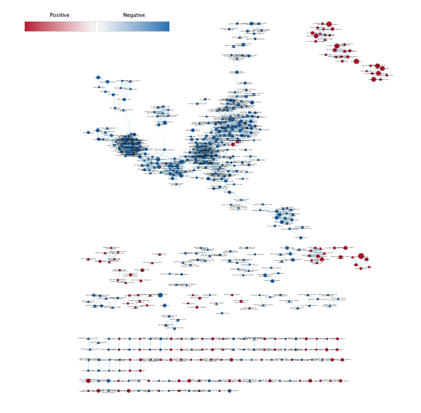

I tried to annotate the regions which have many nodes which are obviously clustered. However, this proved to be a challenge. There was a large section in the middle which could not be easily read, and was difficult to label meaningfully. I have displayed my attempt below (Figure 2). For more detailed publication-ready figure, I have used AutoAnnotate to obtain clearer clusters (Figure 3)

### Figure 2: Annotated network of GSEA results

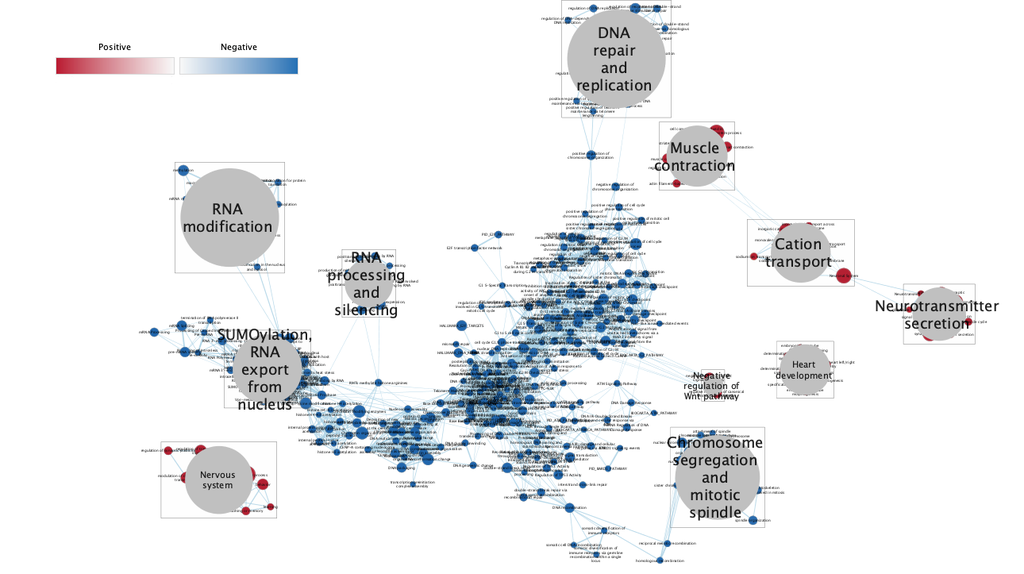

## Background on HDACs and HDAC inhibitors

HDACs (Histone deacetylases) are an important class of enzymes involved in epigenetic regulation of a wide variety of genes in the cell (Eckschlager 2017). When HDACs catalyze deacetylation of key lysine residues on histones, this leads to chromatin condensation, and thus silencing of gene expression (Eckschlager 2017). The opening of chromatin is done by acetylation of those same lysine residues by HATs (histone acetyltransferases)(Eckschlager 2017).There are also proteins other than histones whose activities are affected by acetylation, such as chromatin remodeling proteins, DNA-binding nuclear receptors, DNA repair enzymes, among others, and changes in the balance of HAT/HDAC activity is known to alter various signaling pathways, including the Wnt pathway (Eckschlager 2017).

HDAC inhibitors such as SAHA inhibit the catalytic activity of HDACs, preventing acetyl groups from being removed from target proteins.(Barneda-Zahonero 2012). SAHA inhibits HDACs by chelating the zinc atom in the catalytic site of HDACs, thus blocking catalytic activity (Marks 2007). SAHA is known to inhibit activity of all 11 human class I and class II HDACs (Marks 2007).

## Common themes between my analysis and the Raferi et. al. paper’s analysis

In Assignment 2, I showed that regulation of 6 EP300 target genes (VCAN, CD58, CD200, SIGIRR, CCL2, ICAM2) were downregulated in SAHA-treated dHAECs as compared to DMSO-treated dHAECs, which is what the Rafehi et al. paper also found. Neither my analysis nor the (Rafehi et al. 2017) paper found gene sets from GSEA analysis which correspond to these genes, and there are no gene sets in the .gmt file I used for this assignment that relate specifically to EP300. Therefore, I will compare my GSEA+Enrichment Map results with those from the (Rafehi et al. 2017) paper

In the (Rafehi et al. 2017) paper, they also used GSEA and Cytoscape/Enrichment Map to visualize the themes among gene sets. There are many commonalities between Figure 3 (my network) and theirs (Figure 3 in (Rafehi et al. 2017) ). Cell cycle and DNA replication, RNA processing and transport, Insulin siglnaling, and neuronal systems/ion channels/synapses are among the pathways in their figure which are common to Figure 3 in my analysis, although they did not include as detailed a look at the landscape as I do in Figure 3.

## Interpretation of themes in network diagram

Since HDACs are histone modifying proteins, downregulation of the theme “histone modification” is consistent with SAHA treatment (Figure 3).

Class I HDACs, when over-expressed, result in over-proliferation phenotypes, and their inhibition is known to cause cell cycle arrest, growth inhibition, and apoptosos in cancer (Barneda-Zahonero 2012). In Figure 3, we see themes such as “cell cycle g2”, “chromatid metaphase segregation”, and “mitotic checkpoint integrity” being downregulated, which are related to cell cycle arrest and growth inhibition. This is consistent with inhibition of class I HDACs by SAHA.

Class II HDACs have a more mixed function, and can be pro-proliferative or tumor suppressors depending on the context. HDAC4 activity is known to promote DNA repair and result in a block in cell proliferation (Barneda-Zahonero 2012), and HDAC4 activity is known to be inhibited by SAHA, since it is a class II HDAC (Marks 2007). In Figure 3, the downregulation of themes “DNA repair/replication” (the theme with the most gene sets), “double-stranded break repair”, “D-loop recombination repair” are consistent with inhibition of HDAC4 by SAHA.

HDAC4 is also believed to positively regulate SUMOylation of proteins involved in cognitive function (Yili Wu and Bai 2016). Since SAHA downregulates HDAC4, this could explain the downregulation of the “SUMOylation, RNA nuclear export” theme in Figure 3.

The wide range of proteins whose functions are regulated by HDAC-dependent deacetylation is reflected in the diverse themes present in Figure 3. It is not possible to investigate all of them in detail. Overall, the literature supports the variety of themes in Figure 3, which result from HDAC inhibition by SAHA in dHAECs.

### Figure 3: Themed network diagram of GSEA results

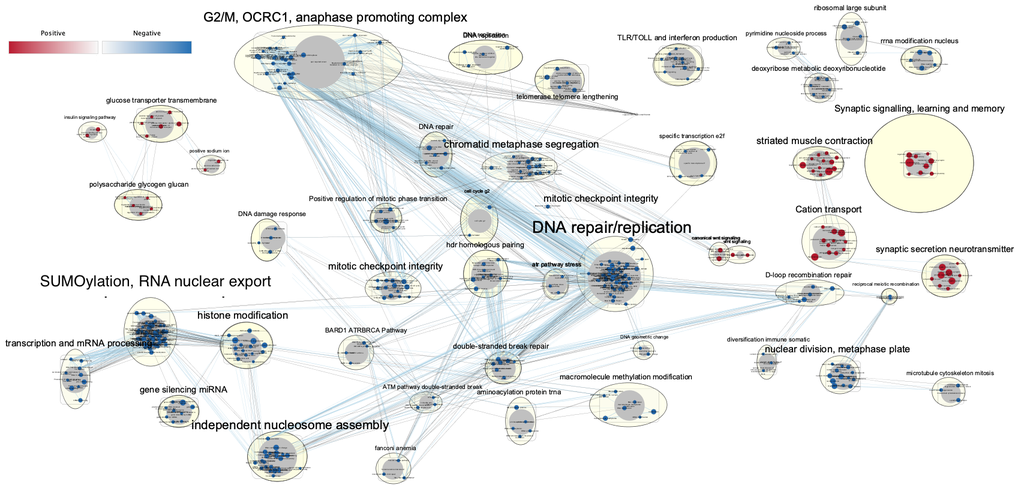

# Wnt pathway - further investigation

## Background and rationale

I have chosen the Wnt pathway as a pathway to investigate in the GSEA non-thresholded results. Wnt-related gene sets are make up 11/296 significant gene sets with p-value threshold of 0.01, including ranks #23 (NEGATIVE REGULATION OF CANONICAL WNT SIGNALING PATHWAY%GOBP%GO:0090090) and #44 (“NEGATIVE REGULATION OF WNT SIGNALING PATHWAY%GOBP%GO:0030178”) in “na_pos” GSEA results. There are no Wnt-related terms in the “na_neg” downregulated sets, suggesting that upregulation of Wnt-related genes is uniquely seen in SAHA-treated dHAECs.

The Wnt pathway is an evolutionarily conserved signalling pathway, and its aberrant activation is know to play a central role in a wide variety of cancers (Andel 2019). There is also literature support for modulation of the Wnt pathway by SAHA. In the (Götze et al. 2014) paper, they show that SAHA attenuates proliferation and induces apoptosis in Wnt-activated colorectal carcinoma cell lines. In the (Sujeong Jang 2018b) paper, they show that expression of most of the Wnt-related genes they were investigating were highly increased following treatment with HDAC inhibitors.

The Wnt pathway is a well-defined pathway with literature support for SAHA effects, so it makes a good candidate for more detailed investigation.

Panel 1: Leading edge genes of GO term GO0090090 also in WP428

| genes |
| --- |
| CSNK1A1 |
| DKK1 |
| DKK2 |
| DVL2 |
| GSK3B |
| NOTUM |
| SFRP1 |
| SOX17 |

## Annotated Wnt pathway diagram from WikiPathways

I have downloaded the WP428 (Wnt Signaling) WikiPathways network using the “Import Network from Public Databases” feature of Cytoscape, and annotated it with the rank file I used as input to my GSEA run (Figure 4). Additionally, the GO term “GO:0090090”, “negative regulation of canonical Wnt signaling pathway”, which is hit #23 of GSEA’s “na_pos” results, has 8 leading edge genes in common with WikiPathway WP428 (Panel 1). All of these genes are in the leading edge of this GSEA result. There are 44 other genes in the leading edge which are not listed in Figure 4, but which are known to negatively regulate Wnt signalling.

DKK1 and SFRP1 are both highly ranked Wnt pathway inhibitors, as can be seen by the (—-| ) inhibitory arrows in Figure 4. SFRP1 inhibits signaling of Wnt proteins directly, whereas DKK1 inhibits LRP5/6, which in turn interact with Frizzled(FZD) receptors (Figure 4). DKK1, a known Wnt antagonist, is epigenetically silenced in a medulloblastoma cell line, and is upregulated upon HDAC inhibition (Vibhakar 2007). Epigenetic silencing of SFRP1 leads to increased survival of renal and breast cancers, and re-rexpression of SFRP1 upon treatment with HDAC inhibitors coincides with reduced cell growth and apoptosis in chemoresistant cancers (Cooper et al. 2012). Additionally, promoter methylation (i.e. repression of transcription) of Wnt antagonists DKK1 and SFRP1 are known events which lead to hyper-activation of the Wnt pathway (Andel 2019). It then follows that an increase in their expression would have the effect of suppressing Wnt signalling.

### Figure 4: Highlighting of leading edge genes in Wnt pathway (Wikipathways, WP428). Circled genes are leading edge genes of GSEA GO term “GO 0090090”

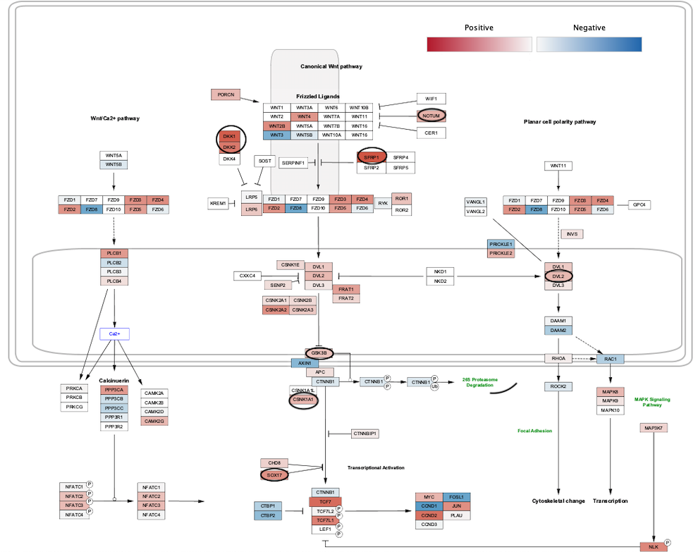